# Ibrahim Aliyev - R Project

**Solutions to the tasks:**

**Reading CSV file**

Our first task is to read csv file. As we changed file format of give xlsx file into csv, and changed working directory into our specified directory, now we can call our file directly in built-in read.csv function. head() function is used to see first 6 row of data.

```r
df<-read.csv("Data3.csv")
head(df)
```

|  | depth | sp | vsh | facies |
| --- | --- | --- | --- | --- |
| 1 | 4346.6 | 12.54381 | 0.10414585 | 0 |
| 2 | 4346.7 | 12.78023 | 0.09642523 | 0 |
| 3 | 4346.8 | 13.02019 | 0.08858898 | 0 |
| 4 | 4346.9 | 13.22106 | 0.08202959 | 0 |
| 5 | 4347.0 | 13.33766 | 0.07822198 | 0 |
| 6 | 4347.1 | 13.37338 | 0.07705545 | 0 |

Task 1 has been completed successfully.

Let us see how to do task 2. Firstly we need to create new column and bind it to our dataframe. There is easy way like below. We create column with values NA and directly bind it to df.

```r
df['lithotype'] <- NA
head(df)
```

|  | depth | sp | vsh | facies | lithotype |
| --- | --- | --- | --- | --- | --- |
| 1 | 4346.6 | 12.54381 | 0.10414585 | 0 | NA |
| 2 | 4346.7 | 12.78023 | 0.09642523 | 0 | NA |
| 3 | 4346.8 | 13.02019 | 0.08858898 | 0 | NA |
| 4 | 4346.9 | 13.22106 | 0.08202959 | 0 | NA |
| 5 | 4347.0 | 13.33766 | 0.07822198 | 0 | NA |
| 6 | 4347.1 | 13.37338 | 0.07705545 | 0 | NA |

Now, as mentioned in the task, we need to specify values for lithotype depending on values of vsh column. My suggestion like below: Firstly, I make all values as ‘S5’, because it is mentioned in section else and we don’t know exact condition for these part. So, let’s do it:

```r
df['lithotype'] <- 'S5'
head(df)
```

|  | depth | sp | vsh | facies | lithotype |
| --- | --- | --- | --- | --- | --- |
| 1 | 4346.6 | 12.54381 | 0.10414585 | 0 | S5 |
| 2 | 4346.7 | 12.78023 | 0.09642523 | 0 | S5 |
| 3 | 4346.8 | 13.02019 | 0.08858898 | 0 | S5 |
| 4 | 4346.9 | 13.22106 | 0.08202959 | 0 | S5 |
| 5 | 4347.0 | 13.33766 | 0.07822198 | 0 | S5 |
| 6 | 4347.1 | 13.37338 | 0.07705545 | 0 | S5 |

Then we assign other values of lithotype for conditions given from values of vsh column. All else values that don’t satisfy any of the given conditions still will be equal to S5.

```r
df[df$vsh<0.2, "lithotype"] <- "S1"
df[df$vsh>0.2 & df$vsh<0.4, "lithotype"] <- "S2"
df[df$vsh>0.4 & df$vsh<0.6, "lithotype"] <- "S3"
df[df$vsh>0.6 & df$vsh<0.8, "lithotype"] <- "S4"
head(df)
```

|  | depth | sp | vsh | facies | lithotype |
| --- | --- | --- | --- | --- | --- |
| 1 | 4346.6 | 12.54381 | 0.10414585 | 0 | S1 |
| 2 | 4346.7 | 12.78023 | 0.09642523 | 0 | S1 |
| 3 | 4346.8 | 13.02019 | 0.08858898 | 0 | S1 |
| 4 | 4346.9 | 13.22106 | 0.08202959 | 0 | S1 |
| 5 | 4347.0 | 13.33766 | 0.07822198 | 0 | S1 |
| 6 | 4347.1 | 13.37338 | 0.07705545 | 0 | S1 |

Task 2 has been completed successfully.

Let us tend to task 3. Dimension of dataframe:

```r
dim(df)
```

```
[1] 3454    5
```

Numebr of rows and columns

```r
nrow(df)
```

```
[1] 3454
```

```r
ncol(df)
```

```
[1] 5
```

Length:

```r
length(df)
```

```
[1] 5
```

We can get types of attributes using attributes(df) and as we will do it for each column:

```r
for (column in names(df))
{
print(typeof(df[column]))
}
```

```
[1] "list"
[1] "list"
[1] "list"
[1] "list"
[1] "list"
```

This operation can be done like below too:

```r
for (column in attributes(df)$names)
{
print(typeof(df[column]))
}
```

```
[1] "list"
[1] "list"
[1] "list"
[1] "list"
[1] "list"
```

Let us print some rows of our dataframe. To do that we specify range of rows in first part of square brackets. Second part is used for colums. Below code will show first 10 rows:

```r
print(df[1:10, ])
```

|  | depth | sp | vsh | facies | lithotype |
| --- | --- | --- | --- | --- | --- |
| 1 | 4346.6 | 12.54381 | 0.10414585 | 0 | S1 |
| 2 | 4346.7 | 12.78023 | 0.09642523 | 0 | S1 |
| 3 | 4346.8 | 13.02019 | 0.08858898 | 0 | S1 |
| 4 | 4346.9 | 13.22106 | 0.08202959 | 0 | S1 |
| 5 | 4347.0 | 13.33766 | 0.07822198 | 0 | S1 |
| 6 | 4347.1 | 13.37338 | 0.07705545 | 0 | S1 |
| 7 | 4347.2 | 13.38550 | 0.07665975 | 0 | S1 |
| 8 | 4347.3 | 13.41665 | 0.07564233 | 0 | S1 |
| 9 | 4347.4 | 13.42869 | 0.07524924 | 0 | S1 |
| 10 | 4347.5 | 13.32127 | 0.07875695 | 0 | S1 |

But there are other built-in functions like head() and tail() to see first 6 and last 6 rows of our data:

```r
head(df)
```

|  | depth | sp | vsh | facies | lithotype |
| --- | --- | --- | --- | --- | --- |
| 1 | 4346.6 | 12.54381 | 0.10414585 | 0 | S1 |
| 2 | 4346.7 | 12.78023 | 0.09642523 | 0 | S1 |
| 3 | 4346.8 | 13.02019 | 0.08858898 | 0 | S1 |
| 4 | 4346.9 | 13.22106 | 0.08202959 | 0 | S1 |
| 5 | 4347.0 | 13.33766 | 0.07822198 | 0 | S1 |
| 6 | 4347.1 | 13.37338 | 0.07705545 | 0 | S1 |

```r
tail(df)
```

|  | depth | sp | vsh | facies | lithotype |
| --- | --- | --- | --- | --- | --- |
| 3449 | 4691.4 | 6.981652 | 0.2857830 | 2 | S2 |
| 3450 | 4691.5 | 5.973287 | 0.3187121 | 2 | S2 |
| 3451 | 4691.6 | 5.073740 | 0.3480875 | 2 | S2 |
| 3452 | 4691.7 | 4.374261 | 0.3709297 | 2 | S2 |
| 3453 | 4691.8 | 3.846707 | 0.3881574 | 2 | S2 |
| 3454 | 4691.9 | 3.409267 | 0.4024424 | 2 | S3 |

Let us see levels of each column:

```r
levels(factor(df$lithotype))
```

```
[1] "S1" "S2" "S3" "S4" "S5"
```

```r
levels(factor(df$facies))
```

```
[1] "0" "1" "2"
```

Now let us discovery statistics of our dataframe. str stands for structure of dataset:

```r
str(df)
```

```
'data.frame':   3454 obs. of  5 variables:
 $ depth    : num  4347 4347 4347 4347 4347 ...
 $ sp       : num  12.5 12.8 13 13.2 13.3 ...
 $ vsh      : num  0.1041 0.0964 0.0886 0.082 0.0782 ...
 $ facies   : int  0 0 0 0 0 0 0 0 0 0 ...
 $ lithotype: chr  "S1" "S1" "S1" "S1" ...
```

Minimum and maximum values can be found using built-in min() and max() functions:

```r
min(df$depth)
```

```
[1] 4346.6
```

```r
max(df$depth)
```

```
[1] 4691.9
```

```r
min(df$sp)
```

```
[1] -14.53372
```

```r
max(df$sp)
```

```
[1] 14.10383
```

```r
min(df$vsh)
```

```
[1] 0.05320196
```

```r
max(df$vsh)
```

```
[1] 0.9883867
```

Let us see mean, standard deviation and variance of column depth:

```r
mean(df$depth)
```

```
[1] 4519.25
```

```r
sd(df$depth)
```

```
[1] 99.72282
```

```r
var(df$depth)
```

```
[1] 9944.642
```

We can easily get first and third quartile, also other quantiles by specifying percent as float number. quantile() function will be used in each case. For example, as first quartile is 25% we will take argument as 0.25, and for third quartile (75%) it will be 0.75:

```r
quantile(df$depth, 0.25) # first quartile for depth column
```

```
     25%
4432.925
```

```r
quantile(df$depth, 0.75) # third quartile for depth column
```

```
     75%
4605.575
```

Summary function gives us minimum, maximum values, 1st and 3rd quartile, mean and median directly for each column that contains numerical data:

```r
summary(df)
```

```
     depth            sp               vsh             facies       lithotype
 Min.   :4347   Min.   :-14.534   Min.   :0.0532   Min.   :0.000   Length:3454
 1st Qu.:4433   1st Qu.: -5.153   1st Qu.:0.1797   1st Qu.:0.000   Class :character
 Median :4519   Median :  6.178   Median :0.3120   Median :2.000   Mode  :character
 Mean   :4519   Mean   :  3.162   Mean   :0.4105   Mean   :1.204
 3rd Qu.:4606   3rd Qu.: 10.231   3rd Qu.:0.6820   3rd Qu.:2.000
 Max.   :4692   Max.   : 14.104   Max.   :0.9884   Max.   :2.000
```

Let us find coefficient of variation for depth column. It is found by dividing standard deviation to mean:

```r
sd(df$depth) / mean(df$depth)
```

```
[1] 0.02206623
```

**Boxplot operations**

Here we comparing columns Depth and Facies:

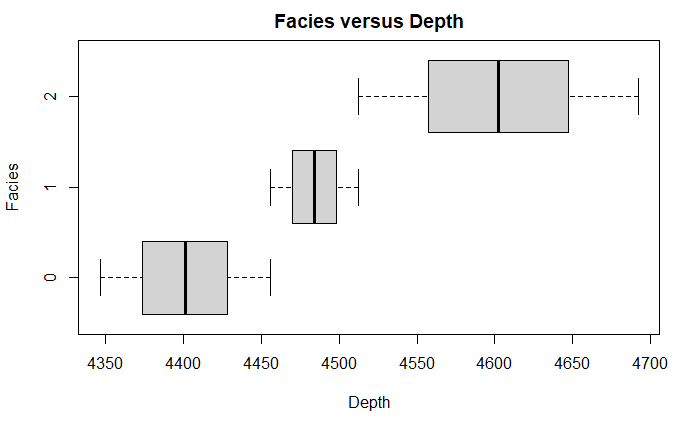

```r
boxplot(df$depth ~ df$facies, horizontal = TRUE, xlab = "Depth", ylab = "Facies", main="Facies versus Depth")
```

Now let us do second boxplot operation (Lithotype versus Depth):

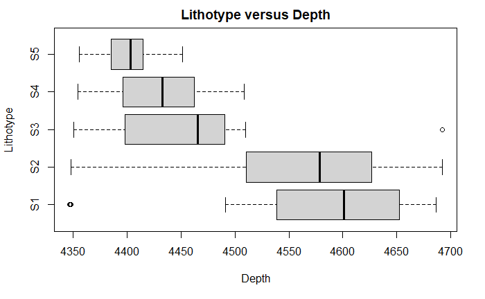

```r
boxplot(df$depth ~ df$lithotype, horizontal = TRUE, xlab = "Depth", ylab = "Lithotype", main="Lithotype versus Depth")
```

**SVM**

Now, about SVM. Abbreviation SVM stands for Support Vector Machines that is supervised learning model and used to analyze data for classification and regression analysis. For the operations in SVM, we will use library caTools for splitting. Let’s install it and check if it is work or not.

```r
install.packages('caTools')
library(caTools)
```

```r
head(df)
```

|  | depth | sp | vsh | facies | lithotype |
| --- | --- | --- | --- | --- | --- |
| 1 | 4346.6 | 12.54381 | 0.10414585 | 0 | S1 |
| 2 | 4346.7 | 12.78023 | 0.09642523 | 0 | S1 |
| 3 | 4346.8 | 13.02019 | 0.08858898 | 0 | S1 |
| 4 | 4346.9 | 13.22106 | 0.08202959 | 0 | S1 |
| 5 | 4347.0 | 13.33766 | 0.07822198 | 0 | S1 |
| 6 | 4347.1 | 13.37338 | 0.07705545 | 0 | S1 |

*SVM for facies column*

Now we should specify our work area. After ignoring sp column and useless other columns we have dataset like below:

```r
svm_df<-subset(df, select = c(depth, vsh, facies))
head(svm_df)
```

|  | depth | vsh | facies |
| --- | --- | --- | --- |
| 1 | 4346.6 | 0.10414585 | 0 |
| 2 | 4346.7 | 0.09642523 | 0 |
| 3 | 4346.8 | 0.08858898 | 0 |
| 4 | 4346.9 | 0.08202959 | 0 |
| 5 | 4347.0 | 0.07822198 | 0 |
| 6 | 4347.1 | 0.07705545 | 0 |

Here, our target feature will be facies column. Let us take it into account like below:

```r
svm_df$facies<-factor(svm_df$facies, levels = c(0,1,2))
```

Now, we are splitting our data into parts like training set and test set:

```r
set.seed(123)
split <- sample.split(svm_df$facies, SplitRatio = 0.75) # 75% and 25%

training_df <- subset(svm_df, split == TRUE)
test_df <- subset(svm_df, split == FALSE)
```

Now let us see how our training set and test dataset look like:

```r
head(training_df) # training dataset
```

|  | depth | vsh | facies |
| --- | --- | --- | --- |
| 1 | 4346.6 | 0.10414585 | 0 |
| 3 | 4346.8 | 0.08858898 | 0 |
| 6 | 4347.1 | 0.07705545 | 0 |
| 7 | 4347.2 | 0.07665975 | 0 |
| 9 | 4347.4 | 0.07524924 | 0 |
| 10 | 4347.5 | 0.07875695 | 0 |

```r
head(test_df) # test dataset
```

|  | depth | vsh | facies |
| --- | --- | --- | --- |
| 2 | 4346.7 | 0.09642523 | 0 |
| 4 | 4346.9 | 0.08202959 | 0 |
| 5 | 4347.0 | 0.07822198 | 0 |
| 8 | 4347.3 | 0.07564233 | 0 |
| 11 | 4347.6 | 0.08861729 | 0 |
| 16 | 4348.1 | 0.18627112 | 0 |

Let us scale our features to the size that computer can easily understand:

```r
training_df[-3] <- scale(training_df[-3])
test_df[-3] <- scale(test_df[-3])
```

After making this operation, our datasets will be like below:

```r
head(training_df)
```

|  | depth | vsh | facies |
| --- | --- | --- | --- |
| 1 | -1.731168 | -1.141100 | 0 |
| 3 | -1.729163 | -1.198700 | 0 |
| 6 | -1.726156 | -1.241404 | 0 |
| 7 | -1.725154 | -1.242869 | 0 |
| 9 | -1.723149 | -1.248091 | 0 |
| 10 | -1.722147 | -1.235104 | 0 |

```r
head(test_df)
```

|  | depth | vsh | facies |
| --- | --- | --- | --- |
| 2 | -1.729691 | -1.1428683 | 0 |
| 4 | -1.727684 | -1.1961669 | 0 |
| 5 | -1.726681 | -1.2102642 | 0 |
| 8 | -1.723670 | -1.2198151 | 0 |
| 11 | -1.720660 | -1.1717765 | 0 |
| 16 | -1.715642 | -0.8102219 | 0 |

Now, we will try to fit SVM to our trained set. But for this operation we need to install package named “e1071”. Let us install it and then continue to fitting.

```r
install.packages('e1071')
library(e1071)
```

Tend to fitting:

```r
svm_classifier <- svm(formula = facies ~ ., data=training_df, type = 'C-classification',kernel="linear")
svm_classifier
```

```
Call:
svm(formula = facies ~ ., data = training_df, type = "C-classification", kernel = "linear")


Parameters:
   SVM-Type:  C-classification
 SVM-Kernel:  linear
       cost:  1

Number of Support Vectors:  238
```

Predicting the test set result:

```r
y_pred = predict(svm_classifier, newdata = test_df[-4])
y_pred
```

```
   2    4    5    8   11   16   20   21   24   31   32   34   37   50   53   58   59   65   67   68   69   71
   0    0    0    0    0    0    0    0    0    0    0    0    0    0    0    0    0    0    0    0    0    0
  84   87   88   89   97  104  106  107  111  114  118  126  132  137  138  139  145  151  173  174  179  181
   0    0    0    0    0    0    0    0    0    0    0    0    0    0    0    0    0    0    0    0    0    0
 189  190  193  195  202  206  219  220  222  230  238  240  248  249  256  260  261  262  264  271  275  277
   0    0    0    0    0    0    0    0    0    0    0    0    0    0    0    0    0    0    0    0    0    0
 281  294  295  296  297  300  301  303  316  317  320  321  327  330  334  340  347  352  356  360  363  366
   0    0    0    0    0    0    0    0    0    0    0    0    0    0    0    0    0    0    0    0    0    0
 373  376  377  380  382  384  386  391  394  400  401  403  412  417  425  430  431  434  445  447  456  457
   0    0    0    0    0    0    0    0    0    0    0    0    0    0    0    0    0    0    0    0    0    0
 458  461  470  472  474  482  485  490  491  496  500  509  513  518  520  527  529  531  534  538  541  543
   0    0    0    0    0    0    0    0    0    0    0    0    0    0    0    0    0    0    0    0    0    0
 545  546  548  549  554  562  563  568  570  572  575  581  582  583  585  589  593  596  599  606  608  614
   0    0    0    0    0    0    0    0    0    0    0    0    0    0    0    0    0    0    0    0    0    0
 616  617  618  619  621  622  623  628  631  632  637  638  639  642  643  647  651  652  656  657  661  662
```

[output cut: 66 more lines]

Let us see confusion matrix like below command:

```r
confusion_matrix <- table(test_df[, 3], y_pred)
confusion_matrix
```

```
   y_pred
      0   1   2
  0 273   0   0
  1   1 140   1
  2   0   0 449
```

Okay, so, we showed confusion matrix and last step is to see accuracy. We look for where Facies column is not equal to our prediction and calculating mean after then. Subtracting it from 1 will give us accuracy level.

```r
svm_accuracy = 1-mean(test_df$facies != y_pred)
svm_accuracy
```

```
[1] 0.9976852
```

Done, great! It is closer to 1. Therefore we can say that it is working well.

*SVM for litgotype column*

Now let us do these steps for lithotype column. Oops, we must ignore sp column. Let us see our dataframe again.

```r
head(df)
```

|  | depth | sp | vsh | facies | lithotype |
| --- | --- | --- | --- | --- | --- |
| 1 | 4346.6 | 12.54381 | 0.10414585 | 0 | S1 |
| 2 | 4346.7 | 12.78023 | 0.09642523 | 0 | S1 |
| 3 | 4346.8 | 13.02019 | 0.08858898 | 0 | S1 |
| 4 | 4346.9 | 13.22106 | 0.08202959 | 0 | S1 |
| 5 | 4347.0 | 13.33766 | 0.07822198 | 0 | S1 |
| 6 | 4347.1 | 13.37338 | 0.07705545 | 0 | S1 |

We have chosen specified columns to continue using subset function:

```r
svm_df<-subset(df, select = c(depth, vsh, lithotype))
head(svm_df)
```

|  | depth | vsh | lithotype |
| --- | --- | --- | --- |
| 1 | 4346.6 | 0.10414585 | S1 |
| 2 | 4346.7 | 0.09642523 | S1 |
| 3 | 4346.8 | 0.08858898 | S1 |
| 4 | 4346.9 | 0.08202959 | S1 |
| 5 | 4347.0 | 0.07822198 | S1 |
| 6 | 4347.1 | 0.07705545 | S1 |

Now, we change our target to lithotype column.

```r
svm_df$lithotype <-factor(svm_df$lithotype, levels = c('S1', 'S2', 'S3', 'S4', 'S5'))
```

Again, we are splitting our data into training set and test set:

```r
set.seed(123)
split <- sample.split(svm_df$lithotype, SplitRatio = 0.75) # 75% and 25%

training_df <- subset(svm_df, split == TRUE)
test_df <- subset(svm_df, split == FALSE)
```

Now let us see how our training set and test dataset look like:

```r
head(training_df) # training dataset
```

|  | depth | vsh | lithotype |
| --- | --- | --- | --- |
| 1 | 4346.6 | 0.10414585 | S1 |
| 3 | 4346.8 | 0.08858898 | S1 |
| 6 | 4347.1 | 0.07705545 | S1 |
| 7 | 4347.2 | 0.07665975 | S1 |
| 9 | 4347.4 | 0.07524924 | S1 |
| 10 | 4347.5 | 0.07875695 | S1 |

```r
head(test_df) # test dataset
```

|  | depth | vsh | lithotype |
| --- | --- | --- | --- |
| 2 | 4346.7 | 0.09642523 | S1 |
| 4 | 4346.9 | 0.08202959 | S1 |
| 5 | 4347.0 | 0.07822198 | S1 |
| 8 | 4347.3 | 0.07564233 | S1 |
| 11 | 4347.6 | 0.08861729 | S1 |
| 16 | 4348.1 | 0.18627112 | S1 |

Let us scale our features to the size that computer can easily understand:

```r
training_df[-3] <- scale(training_df[-3])
test_df[-3] <- scale(test_df[-3])
```

After making this operation, our datasets will be like below:

```r
head(training_df)
```

|  | depth | vsh | lithotype |
| --- | --- | --- | --- |
| 1 | -1.724967 | -1.135238 | S1 |
| 3 | -1.722964 | -1.192818 | S1 |
| 6 | -1.719959 | -1.235507 | S1 |
| 7 | -1.718957 | -1.236971 | S1 |
| 9 | -1.716953 | -1.242192 | S1 |
| 10 | -1.715952 | -1.229209 | S1 |

```r
head(test_df)
```

|  | depth | vsh | lithotype |
| --- | --- | --- | --- |
| 2 | -1.748567 | -1.1601657 | S1 |
| 4 | -1.746556 | -1.2135070 | S1 |
| 5 | -1.745551 | -1.2276157 | S1 |
| 8 | -1.742535 | -1.2371743 | S1 |
| 11 | -1.739519 | -1.1890971 | S1 |
| 16 | -1.734492 | -0.8272523 | S1 |

Now, we will try to fit SVM to our trained set for column lithotype. As we already installed needed package, let us fit directly.

```r
svm_classifier <- svm(formula = lithotype ~ ., data=training_df, type = 'C-classification',kernel="linear")
svm_classifier
```

```
Call:
svm(formula = lithotype ~ ., data = training_df, type = "C-classification", kernel = "linear")


Parameters:
   SVM-Type:  C-classification
 SVM-Kernel:  linear
       cost:  1

Number of Support Vectors:  583
```

Predicting the test set result:

```r
y_pred = predict(svm_classifier, newdata = test_df[-3])
y_pred
```

```
   2    4    5    8   11   16   18   20   29   35   38   59   67   68   71   72   79   85   90   92   93   97
  S1   S1   S1   S1   S1   S1   S2   S2   S2   S2   S2   S2   S2   S2   S3   S3   S4   S4   S4   S5   S5   S5
 100  102  108  112  123  128  130  136  137  138  145  159  165  169  171  175  180  181  183  192  194  195
  S5   S5   S5   S5   S5   S5   S5   S4   S4   S4   S4   S5   S4   S4   S4   S5   S5   S5   S5   S4   S4   S4
 199  206  207  221  231  233  236  238  241  249  250  254  257  258  261  266  268  269  271  272  288  290
  S4   S4   S4   S3   S4   S4   S4   S5   S5   S4   S4   S4   S4   S3   S3   S3   S3   S3   S3   S2   S2   S2
 291  292  293  306  309  311  312  316  317  318  321  323  325  332  339  342  343  347  354  358  362  382
  S2   S2   S2   S3   S3   S3   S3   S4   S4   S4   S4   S4   S4   S5   S5   S5   S5   S4   S4   S4   S4   S5
 385  393  396  398  399  401  405  408  412  415  416  418  423  427  429  434  436  437  438  439  443  448
  S5   S5   S5   S5   S5   S5   S4   S4   S4   S3   S3   S3   S2   S2   S2   S2   S3   S3   S3   S4   S4   S5
 452  453  454  457  471  473  475  477  479  481  493  497  499  500  508  510  519  522  528  529  530  531
  S5   S5   S5   S5   S5   S5   S5   S5   S5   S5   S4   S4   S4   S4   S3   S3   S4   S5   S5   S5   S5   S5
 532  535  540  543  544  560  561  565  573  574  580  582  583  592  594  596  604  607  612  619  621  624
  S5   S5   S5   S5   S5   S4   S4   S4   S5   S5   S5   S5   S5   S5   S5   S5   S5   S5   S5   S5   S5   S5
 628  635  640  642  646  657  662  665  666  668  669  672  674  675  677  679  685  689  690  693  700  702
  S5   S5   S5   S5   S5   S4   S4   S4   S4   S5   S5   S5   S5   S5   S5   S5   S5   S5   S5   S5   S5   S5
 704  707  713  715  719  720  721  739  741  745  747  748  753  756  760  761  762  764  781  786  791  792
  S5   S5   S5   S4   S4   S4   S4   S3   S3   S3   S3   S3   S3   S3   S3   S3   S3   S3   S4   S4   S4   S4
 796  798  804  806  808  814  815  816  817  819  824  829  832  833  834  835  840  841  843  846  848  853
  S4   S4   S4   S4   S4   S4   S4   S4   S4   S4   S4   S4   S4   S4   S4   S4   S4   S4   S4   S4   S4   S4
 854  873  883  884  885  889  893  896  897  900  906  910  924  925  932  933  935  937  938  943  948  953
  S4   S4   S3   S3   S2   S2   S2   S2   S2   S2   S2   S3   S4   S4   S4   S4   S4   S4   S4   S4   S4   S4
 956  958  959  962  963  966  972  975  982  984  995  997 1000 1003 1008 1009 1011 1013 1017 1021 1031 1032
  S4   S4   S4   S4   S4   S4   S4   S4   S4   S4   S5   S4   S4   S4   S5   S5   S5   S5   S5   S5   S5   S5
1050 1058 1062 1065 1068 1073 1075 1083 1087 1090 1093 1097 1099 1102 1104 1110 1119 1124 1128 1134 1135 1136
  S4   S4   S4   S4   S4   S4   S4   S4   S4   S4   S4   S4   S4   S3   S3   S3   S2   S2   S2   S3   S3   S3
1141 1148 1152 1154 1160 1162 1164 1170 1175 1198 1201 1208 1210 1211 1215 1219 1222 1225 1227 1229 1239 1243
  S3   S4   S4   S4   S4   S4   S4   S4   S4   S2   S2   S2   S2   S2   S2   S2   S3   S3   S3   S3   S2   S2
1254 1258 1265 1268 1273 1280 1299 1302 1308 1312 1318 1320 1322 1327 1328 1334 1336 1338 1343 1350 1351 1352
  S4   S4   S4   S4   S3   S3   S4   S4   S4   S4   S4   S4   S4   S4   S4   S4   S4   S4   S4   S4   S4   S4
1358 1360 1366 1367 1369 1372 1373 1377 1378 1381 1387 1388 1391 1392 1399 1400 1410 1411 1413 1423 1433 1436
  S4   S4   S4   S4   S3   S3   S3   S2   S2   S2   S2   S2   S3   S3   S3   S3   S4   S4   S4   S4   S4   S4
1440 1445 1449 1450 1453 1455 1456 1460 1463 1466 1471 1477 1480 1483 1485 1488 1495 1496 1503 1505 1506 1513
  S3   S2   S1   S1   S2   S2   S2   S2   S2   S2   S3   S3   S3   S3   S3   S3   S3   S3   S2   S2   S1   S1
1514 1516 1519 1523 1524 1528 1538 1544 1550 1555 1558 1567 1569 1574 1581 1582 1585 1586 1590 1592 1596 1603
  S1   S1   S2   S2   S2   S2   S2   S2   S2   S2   S2   S2   S2   S2   S2   S3   S3   S3   S3   S3   S3   S3
1607 1611 1612 1617 1619 1624 1626 1627 1630 1635 1637 1644 1647 1650 1652 1656 1669 1672 1677 1678 1684 1686
  S4   S4   S4   S4   S4   S3   S3   S3   S3   S2   S2   S2   S2   S2   S2   S1   S1   S1   S1   S1   S1   S1
1687 1688 1690 1703 1706 1707 1708 1716 1723 1725 1726 1730 1733 1737 1745 1751 1755 1764 1768 1772 1774 1776
  S1   S1   S1   S1   S1   S1   S1   S1   S1   S1   S1   S1   S1   S1   S1   S1   S2   S2   S2   S2   S2   S2
```

[output cut: 26 more lines]

```
2853 2858 2868 2874 2875 2876 2892 2895 2910 2915 2917 2918 2920 2923 2925 2928 2929 2932 2938 2942 2945 2947
  S1   S1   S1   S1   S1   S1   S1   S1   S1   S1   S1   S1   S1   S1   S1   S1   S1   S1   S1   S2   S2   S2
2952 2958 2961 2964 2970 2985 2987 2989 2996 3004 3006 3012 3015 3018 3024 3027 3035 3038 3041 3045 3047 3055
  S2   S2   S2   S2   S2   S2   S2   S2   S2   S2   S2   S2   S2   S2   S2   S2   S2   S2   S2   S2   S2   S1
3063 3076 3077 3079 3085 3087 3090 3095 3096 3100 3111 3114 3119 3120 3129 3137 3146 3152 3158 3162 3165 3176
  S1   S1   S1   S1   S1   S1   S1   S1   S1   S1   S1   S1   S1   S1   S1   S1   S1   S1   S1   S1   S1   S2
3179 3181 3193 3195 3199 3202 3206 3212 3215 3216 3220 3221 3223 3227 3228 3229 3233 3236 3241 3244 3250 3251
  S2   S2   S1   S1   S1   S1   S1   S1   S1   S1   S1   S1   S1   S1   S1   S1   S1   S1   S1   S1   S1   S1
3261 3265 3267 3269 3271 3274 3275 3277 3289 3292 3297 3299 3314 3315 3320 3321 3322 3323 3329 3331 3334 3335
  S2   S2   S2   S1   S1   S1   S1   S1   S1   S1   S2   S2   S2   S2   S2   S2   S2   S2   S2   S2   S2   S2
3338 3343 3348 3349 3351 3355 3360 3364 3366 3368 3372 3378 3380 3381 3391 3399 3401 3410 3419 3426 3431 3432
  S2   S2   S2   S2   S2   S2   S1   S1   S1   S1   S1   S1   S1   S1   S1   S1   S2   S2   S2   S2   S2   S2
3439 3442 3443 3447 3449 3452
  S2   S2   S2   S2   S2   S2
Levels: S1 S2 S3 S4 S5
```

Let us see confusion matrix like below command:

```r
confusion_matrix <- table(test_df[, 3], y_pred)
confusion_matrix
```

```
    y_pred
      S1  S2  S3  S4  S5
  S1 248   3   0   0   0
  S2   0 281   1   0   0
  S3   0   3  74   0   0
  S4   0   0   0 158   0
  S5   0   0   0   3  93
```

And exciting moment! Last one, accuracy! We will see.

```r
svm_accuracy = 1-mean(test_df$lithotype != y_pred)
svm_accuracy
```

```
[1] 0.9884259
```

Great! Again we got value that is closer to 1. So, this means we did awesome job. Let’s tend to KNN!

**KNN**

KNN stands for K-nearest neighbors and it is one of the supervised learning methods that is used for classification and regression. We need to install class package.

```r
install.packages("class")
library(class)
```

*KNN for facies column*

We will use below dataset now:

```r
knn_df <- subset(df, select = c(depth, vsh, facies))
head(knn_df)
```

|  | depth | vsh | facies |
| --- | --- | --- | --- |
| 1 | 4346.6 | 0.10414585 | 0 |
| 2 | 4346.7 | 0.09642523 | 0 |
| 3 | 4346.8 | 0.08858898 | 0 |
| 4 | 4346.9 | 0.08202959 | 0 |
| 5 | 4347.0 | 0.07822198 | 0 |
| 6 | 4347.1 | 0.07705545 | 0 |

Here, our target feature is facies column. Let us take it into account like below:

```r
knn_df$facies<-factor(knn_df$facies, levels = c(0,1,2))
```

Now, we are splitting our data into parts like training set and test set:

```r
set.seed(123)
split <- sample.split(knn_df$facies, SplitRatio = 0.75) # 75% and 25%

training_df <- subset(knn_df, split == TRUE)
test_df <- subset(knn_df, split == FALSE)
```

Let us scale our features to the size that computer can easily understand:

```r
training_df[-3] <- scale(training_df[-3])
test_df[-3] <- scale(test_df[-3])
```

After making this operation, our datasets will be like below:

```r
head(training_df)
```

|  | depth | vsh | facies |
| --- | --- | --- | --- |
| 1 | -1.731168 | -1.141100 | 0 |
| 3 | -1.729163 | -1.198700 | 0 |
| 6 | -1.726156 | -1.241404 | 0 |
| 7 | -1.725154 | -1.242869 | 0 |
| 9 | -1.723149 | -1.248091 | 0 |
| 10 | -1.722147 | -1.235104 | 0 |

```r
head(test_df)
```

|  | depth | vsh | facies |
| --- | --- | --- | --- |
| 2 | -1.729691 | -1.1428683 | 0 |
| 4 | -1.727684 | -1.1961669 | 0 |
| 5 | -1.726681 | -1.2102642 | 0 |
| 8 | -1.723670 | -1.2198151 | 0 |
| 11 | -1.720660 | -1.1717765 | 0 |
| 16 | -1.715642 | -0.8102219 | 0 |

Let us fit KNN model to fit train dataset, I am going to take k as 3:

```r
knn_classifier <- knn(train = training_df[,-3], test = test_df[,-3], cl = training_df$facies, k=3)
knn_classifier
```

```
  [1] 0 0 0 0 0 0 0 0 0 0 0 0 0 0 0 0 0 0 0 0 0 0 0 0 0 0 0 0 0 0 0 0 0 0 0 0 0 0 0 0 0 0 0 0 0 0 0 0 0 0 0 0 0
 [54] 0 0 0 0 0 0 0 0 0 0 0 0 0 0 0 0 0 0 0 0 0 0 0 0 0 0 0 0 0 0 0 0 0 0 0 0 0 0 0 0 0 0 0 0 0 0 0 0 0 0 0 0 0
[107] 0 0 0 0 0 0 0 0 0 0 0 0 0 0 0 0 0 0 0 0 0 0 0 0 0 0 0 0 0 0 0 0 0 0 0 0 0 0 0 0 0 0 0 0 0 0 0 0 0 0 0 0 0
[160] 0 0 0 0 0 0 0 0 0 0 0 0 0 0 0 0 0 0 0 0 0 0 0 0 0 0 0 0 0 0 0 0 0 0 0 0 0 0 0 0 0 0 0 0 0 0 0 0 0 0 0 0 0
[213] 0 0 0 0 0 0 0 0 0 0 0 0 0 0 0 0 0 0 0 0 0 0 0 0 0 0 0 0 0 0 0 0 0 0 0 0 0 0 0 0 0 0 0 0 0 0 0 0 0 0 0 0 0
[266] 0 1 1 0 0 0 0 1 0 0 1 1 1 1 1 1 1 1 1 1 1 1 1 1 1 1 1 1 1 1 1 1 1 1 1 1 1 1 1 1 1 1 1 1 1 1 1 1 1 1 1 1 1
[319] 1 1 1 1 1 1 1 1 1 1 1 1 1 1 1 1 1 1 1 1 1 1 1 1 1 1 1 1 1 1 1 1 1 1 1 1 1 1 1 1 1 1 1 1 1 1 1 1 1 1 1 1 1
[372] 1 1 1 1 1 1 1 1 1 1 1 1 1 1 1 1 1 1 1 1 1 1 1 1 1 1 1 1 1 1 1 1 1 1 1 1 1 1 1 1 1 1 1 2 2 2 2 2 2 2 2 2 2
[425] 2 2 2 2 2 2 2 2 2 2 2 2 2 2 2 2 2 2 2 2 2 2 2 2 2 2 2 2 2 2 2 2 2 2 2 2 2 2 2 2 2 2 2 2 2 2 2 2 2 2 2 2 2
[478] 2 2 2 2 2 2 2 2 2 2 2 2 2 2 2 2 2 2 2 2 2 2 2 2 2 2 2 2 2 2 2 2 2 2 2 2 2 2 2 2 2 2 2 2 2 2 2 2 2 2 2 2 2
[531] 2 2 2 2 2 2 2 2 2 2 2 2 2 2 2 2 2 2 2 2 2 2 2 2 2 2 2 2 2 2 2 2 2 2 2 2 2 2 2 2 2 2 2 2 2 2 2 2 2 2 2 2 2
[584] 2 2 2 2 2 2 2 2 2 2 2 2 2 2 2 2 2 2 2 2 2 2 2 2 2 2 2 2 2 2 2 2 2 2 2 2 2 2 2 2 2 2 2 2 2 2 2 2 2 2 2 2 2
[637] 2 2 2 2 2 2 2 2 2 2 2 2 2 2 2 2 2 2 2 2 2 2 2 2 2 2 2 2 2 2 2 2 2 2 2 2 2 2 2 2 2 2 2 2 2 2 2 2 2 2 2 2 2
[690] 2 2 2 2 2 2 2 2 2 2 2 2 2 2 2 2 2 2 2 2 2 2 2 2 2 2 2 2 2 2 2 2 2 2 2 2 2 2 2 2 2 2 2 2 2 2 2 2 2 2 2 2 2
[743] 2 2 2 2 2 2 2 2 2 2 2 2 2 2 2 2 2 2 2 2 2 2 2 2 2 2 2 2 2 2 2 2 2 2 2 2 2 2 2 2 2 2 2 2 2 2 2 2 2 2 2 2 2
[796] 2 2 2 2 2 2 2 2 2 2 2 2 2 2 2 2 2 2 2 2 2 2 2 2 2 2 2 2 2 2 2 2 2 2 2 2 2 2 2 2 2 2 2 2 2 2 2 2 2 2 2 2 2
[849] 2 2 2 2 2 2 2 2 2 2 2 2 2 2 2 2
Levels: 0 1 2
```

Let us see confusion matrix like below command:

```r
confusion_matrix <- table(test_df[, 3], knn_classifier)
confusion_matrix
```

```
   knn_classifier
      0   1   2
  0 270   3   0
  1   2 139   1
  2   0   0 449
```

Okay, so, we showed confusion matrix and last step is to see accuracy.

```r
knn_accuracy = 1-mean(test_df$facies != knn_classifier)
knn_accuracy
```

```
[1] 0.9930556
```

Again, close to 1. So it is great!

*KNN for lithotype*

Let us specify our dataset:

```r
knn_df <- subset(df, select = c(depth, vsh, lithotype))
head(knn_df)
```

|  | depth | vsh | lithotype |
| --- | --- | --- | --- |
| 1 | 4346.6 | 0.10414585 | S1 |
| 2 | 4346.7 | 0.09642523 | S1 |
| 3 | 4346.8 | 0.08858898 | S1 |
| 4 | 4346.9 | 0.08202959 | S1 |
| 5 | 4347.0 | 0.07822198 | S1 |
| 6 | 4347.1 | 0.07705545 | S1 |

Here, our target feature is lithotype column. Let us take it into account like below:

```r
knn_df$lithotype<-factor(knn_df$lithotype, levels = c('S1', 'S2', 'S3', 'S4', 'S5'))
```

Now, we are splitting our data into parts like training set and test set:

```r
set.seed(123)
split <- sample.split(knn_df$lithotype, SplitRatio = 0.75) # 75% and 25%

training_df <- subset(knn_df, split == TRUE)
test_df <- subset(knn_df, split == FALSE)
```

Let us scale our features to the size that computer can easily understand:

```r
training_df[-3] <- scale(training_df[-3])
test_df[-3] <- scale(test_df[-3])
```

After making this operation, our datasets will be like below:

```r
head(training_df)
```

|  | depth | vsh | lithotype |
| --- | --- | --- | --- |
| 1 | -1.724967 | -1.135238 | S1 |
| 3 | -1.722964 | -1.192818 | S1 |
| 6 | -1.719959 | -1.235507 | S1 |
| 7 | -1.718957 | -1.236971 | S1 |
| 9 | -1.716953 | -1.242192 | S1 |
| 10 | -1.715952 | -1.229209 | S1 |

```r
head(test_df)
```

|  | depth | vsh | lithotype |
| --- | --- | --- | --- |
| 2 | -1.748567 | -1.1601657 | S1 |
| 4 | -1.746556 | -1.2135070 | S1 |
| 5 | -1.745551 | -1.2276157 | S1 |
| 8 | -1.742535 | -1.2371743 | S1 |
| 11 | -1.739519 | -1.1890971 | S1 |
| 16 | -1.734492 | -0.8272523 | S1 |

Let us fit KNN model to fit train dataset, I am going to take k as 3:

```r
knn_classifier <- knn(train = training_df[,-3], test = test_df[,-3], cl = training_df$lithotype, k=3)
knn_classifier
```

```
  [1] S1 S1 S1 S1 S1 S1 S2 S2 S2 S2 S2 S2 S2 S2 S3 S3 S4 S4 S4 S5 S5 S5 S5 S5 S5 S5 S5 S5 S5 S4 S4 S4 S4 S5 S4
 [36] S4 S4 S5 S5 S5 S5 S4 S4 S4 S4 S4 S4 S3 S4 S4 S5 S5 S5 S4 S4 S4 S4 S3 S3 S3 S3 S3 S3 S2 S2 S2 S2 S2 S2 S3
 [71] S3 S3 S3 S4 S4 S4 S4 S4 S4 S5 S5 S5 S5 S4 S4 S4 S4 S5 S5 S5 S5 S5 S5 S5 S4 S4 S4 S3 S3 S3 S2 S2 S2 S3 S3
[106] S3 S3 S3 S4 S5 S5 S5 S5 S5 S5 S5 S5 S5 S5 S5 S5 S4 S4 S4 S3 S3 S4 S5 S5 S5 S5 S5 S5 S5 S5 S5 S5 S4 S4 S4
[141] S5 S5 S5 S5 S5 S5 S5 S5 S5 S5 S5 S5 S5 S5 S5 S5 S5 S5 S5 S4 S4 S4 S5 S5 S5 S5 S5 S5 S5 S5 S5 S5 S5 S5 S5
[176] S5 S5 S5 S5 S5 S4 S4 S4 S3 S3 S3 S3 S3 S3 S3 S3 S3 S3 S3 S4 S4 S4 S4 S4 S4 S4 S4 S4 S4 S4 S4 S4 S4 S4 S4
[211] S4 S4 S4 S4 S4 S4 S4 S4 S4 S4 S4 S4 S3 S3 S2 S2 S2 S2 S2 S2 S2 S3 S4 S4 S4 S4 S4 S4 S4 S4 S4 S4 S4 S4 S4
[246] S4 S4 S4 S4 S4 S4 S5 S5 S5 S4 S4 S5 S5 S5 S5 S5 S5 S5 S5 S4 S4 S4 S4 S4 S4 S4 S4 S4 S4 S4 S4 S4 S3 S3 S3
[281] S2 S2 S2 S3 S3 S3 S3 S4 S4 S4 S4 S4 S4 S4 S4 S2 S2 S2 S2 S2 S2 S3 S3 S3 S3 S3 S2 S2 S4 S4 S4 S4 S3 S3 S4
[316] S4 S4 S4 S4 S4 S4 S4 S4 S4 S4 S4 S4 S4 S4 S4 S4 S4 S4 S3 S3 S3 S3 S2 S2 S2 S2 S3 S3 S3 S3 S3 S4 S4 S4 S4
[351] S4 S4 S3 S2 S1 S1 S1 S2 S2 S2 S2 S2 S3 S3 S3 S3 S3 S3 S3 S3 S2 S2 S1 S1 S1 S1 S2 S2 S2 S2 S2 S2 S2 S2 S2
[386] S2 S2 S2 S3 S3 S3 S3 S3 S3 S3 S3 S4 S4 S4 S4 S4 S3 S3 S3 S3 S3 S2 S2 S2 S2 S2 S1 S1 S1 S1 S1 S1 S1 S1 S1
[421] S1 S1 S1 S1 S1 S1 S1 S1 S1 S1 S1 S1 S1 S1 S2 S2 S2 S2 S2 S2 S2 S2 S2 S1 S1 S1 S1 S1 S1 S1 S1 S1 S1 S1 S1
[456] S1 S1 S1 S1 S1 S1 S1 S1 S1 S1 S2 S2 S2 S1 S1 S1 S1 S1 S1 S1 S1 S1 S1 S1 S1 S1 S1 S1 S1 S1 S1 S1 S1 S1 S2
[491] S2 S2 S2 S2 S1 S1 S1 S1 S2 S2 S2 S2 S2 S2 S2 S2 S2 S2 S2 S2 S2 S2 S2 S2 S2 S2 S2 S2 S2 S1 S1 S1 S1 S1 S2
[526] S2 S2 S2 S2 S1 S1 S1 S1 S1 S1 S1 S1 S1 S1 S1 S1 S1 S1 S1 S1 S1 S1 S1 S2 S2 S2 S2 S2 S2 S2 S2 S2 S2 S2 S2
[561] S2 S2 S2 S2 S2 S2 S2 S2 S2 S2 S2 S2 S2 S2 S2 S1 S1 S1 S2 S2 S2 S2 S2 S2 S2 S2 S2 S2 S2 S2 S2 S2 S2 S2 S2
[596] S2 S2 S2 S2 S2 S2 S2 S1 S1 S1 S1 S2 S2 S2 S2 S2 S2 S2 S2 S2 S2 S2 S2 S2 S1 S1 S1 S1 S1 S1 S1 S1 S1 S1 S1
[631] S1 S1 S1 S1 S2 S2 S2 S2 S2 S2 S2 S2 S2 S2 S2 S2 S2 S2 S2 S2 S2 S1 S1 S1 S1 S2 S2 S2 S2 S1 S1 S1 S1 S1 S1
[666] S1 S1 S1 S1 S1 S1 S1 S1 S1 S1 S1 S1 S1 S1 S1 S1 S1 S2 S2 S2 S2 S2 S2 S2 S1 S1 S1 S2 S2 S2 S2 S2 S2 S2 S2
[701] S2 S2 S2 S2 S2 S2 S1 S1 S2 S2 S2 S2 S2 S2 S1 S1 S1 S1 S1 S2 S2 S1 S1 S1 S1 S1 S1 S1 S1 S1 S1 S1 S1 S1 S1
[736] S1 S1 S1 S1 S1 S1 S1 S1 S1 S1 S2 S2 S2 S2 S2 S2 S2 S2 S2 S2 S2 S2 S2 S2 S2 S2 S2 S2 S2 S2 S2 S2 S2 S2 S1
[771] S1 S1 S1 S1 S1 S1 S1 S1 S1 S1 S1 S1 S1 S1 S1 S1 S1 S1 S1 S1 S1 S2 S2 S2 S1 S1 S1 S1 S1 S1 S1 S1 S1 S1 S1
[806] S1 S1 S1 S1 S1 S1 S1 S1 S1 S2 S2 S2 S2 S1 S1 S1 S1 S1 S1 S2 S2 S2 S2 S2 S2 S2 S2 S2 S2 S2 S2 S2 S2 S2 S2
[841] S2 S2 S1 S1 S1 S1 S1 S1 S1 S1 S1 S1 S2 S2 S2 S2 S2 S2 S2 S2 S2 S2 S2 S2
Levels: S1 S2 S3 S4 S5
```

Let us see confusion matrix like below command:

```r
confusion_matrix <- table(test_df[, 3], knn_classifier)
confusion_matrix
```

```
    knn_classifier
      S1  S2  S3  S4  S5
  S1 245   6   0   0   0
  S2   3 276   3   0   0
  S3   0   0  77   0   0
  S4   0   0   2 153   3
  S5   0   0   0   0  96
```

So, as we showed confusion matrix and last step is to see accuracy.

```r
knn_accuracy = 1-mean(test_df$lithotype != knn_classifier)
knn_accuracy
```

```
[1] 0.9803241
```

Works fine!

**RF**

RF stands for Random Forest and is an ensemble learning method that is used for classification and regression. To work with the random forest we are installing the library named “randomForest”.

```r
install.packages("randomForest")
library(randomForest)
```

*RF for facies*

We will use below dataset now:

```r
rf_df <- subset(df, select = c(depth, vsh, facies))
head(rf_df)
```

|  | depth | vsh | facies |
| --- | --- | --- | --- |
| 1 | 4346.6 | 0.10414585 | 0 |
| 2 | 4346.7 | 0.09642523 | 0 |
| 3 | 4346.8 | 0.08858898 | 0 |
| 4 | 4346.9 | 0.08202959 | 0 |
| 5 | 4347.0 | 0.07822198 | 0 |
| 6 | 4347.1 | 0.07705545 | 0 |

Here, our target feature is facies column. Let us take it into account like below:

```r
rf_df$facies<-factor(rf_df$facies, levels = c(0,1,2))
```

Now, we are splitting our data into parts like training set and test set:

```r
set.seed(123)
split <- sample.split(rf_df$facies, SplitRatio = 0.75) # 75% and 25%

training_df <- subset(rf_df, split == TRUE)
test_df <- subset(rf_df, split == FALSE)
```

Let us scale our features to the size that computer can easily understand:

```r
training_df[-3] <- scale(training_df[-3])
test_df[-3] <- scale(test_df[-3])
```

After making this operation, our datasets will be like below:

```r
head(training_df)
```

|  | depth | vsh | facies |
| --- | --- | --- | --- |
| 1 | -1.731168 | -1.141100 | 0 |
| 3 | -1.729163 | -1.198700 | 0 |
| 6 | -1.726156 | -1.241404 | 0 |
| 7 | -1.725154 | -1.242869 | 0 |
| 9 | -1.723149 | -1.248091 | 0 |
| 10 | -1.722147 | -1.235104 | 0 |

```r
head(test_df)
```

|  | depth | vsh | facies |
| --- | --- | --- | --- |
| 2 | -1.729691 | -1.1428683 | 0 |
| 4 | -1.727684 | -1.1961669 | 0 |
| 5 | -1.726681 | -1.2102642 | 0 |
| 8 | -1.723670 | -1.2198151 | 0 |
| 11 | -1.720660 | -1.1717765 | 0 |
| 16 | -1.715642 | -0.8102219 | 0 |

Let us fit RF model to fit train dataset:

```r
rf_classifier = randomForest(x = training_df[,-3], y = training_df$facies, ntree = 500)
rf_classifier
```

```
Call:
 randomForest(x = training_df[, -3], y = training_df$facies, ntree = 500)
               Type of random forest: classification
                     Number of trees: 500
No. of variables tried at each split: 1

        OOB estimate of  error rate: 0.08%
Confusion matrix:
    0   1    2  class.error
0 818   1    0 0.0012210012
1   0 424    0 0.0000000000
2   0   1 1346 0.0007423905
```

Let us go to prediction step for test set results:

```r
y_pred = predict(rf_classifier, newdata = test_df[-3])
y_pred
```

```
   2    4    5    8   11   16   20   21   24   31   32   34   37   50   53   58   59   65   67   68   69   71
   0    0    0    0    0    0    0    0    0    0    0    0    0    0    0    0    0    0    0    0    0    0
  84   87   88   89   97  104  106  107  111  114  118  126  132  137  138  139  145  151  173  174  179  181
   0    0    0    0    0    0    0    0    0    0    0    0    0    0    0    0    0    0    0    0    0    0
 189  190  193  195  202  206  219  220  222  230  238  240  248  249  256  260  261  262  264  271  275  277
   0    0    0    0    0    0    0    0    0    0    0    0    0    0    0    0    0    0    0    0    0    0
 281  294  295  296  297  300  301  303  316  317  320  321  327  330  334  340  347  352  356  360  363  366
   0    0    0    0    0    0    0    0    0    0    0    0    0    0    0    0    0    0    0    0    0    0
 373  376  377  380  382  384  386  391  394  400  401  403  412  417  425  430  431  434  445  447  456  457
   0    0    0    0    0    0    0    0    0    0    0    0    0    0    0    0    0    0    0    0    0    0
 458  461  470  472  474  482  485  490  491  496  500  509  513  518  520  527  529  531  534  538  541  543
   0    0    0    0    0    0    0    0    0    0    0    0    0    0    0    0    0    0    0    0    0    0
 545  546  548  549  554  562  563  568  570  572  575  581  582  583  585  589  593  596  599  606  608  614
   0    0    0    0    0    0    0    0    0    0    0    0    0    0    0    0    0    0    0    0    0    0
 616  617  618  619  621  622  623  628  631  632  637  638  639  642  643  647  651  652  656  657  661  662
```

[output cut: 66 more lines]

Let us see confusion matrix like below command:

```r
confusion_matrix <- table(test_df[, 3], y_pred)
confusion_matrix
```

```
   y_pred
      0   1   2
  0 272   1   0
  1   0 141   1
  2   0   0 449
```

Okay, so, we showed confusion matrix and last step is to see accuracy.

```r
rf_accuracy = 1-mean(test_df$facies != y_pred)
rf_accuracy
```

```
[1] 0.9976852
```

Great result! Now, let us do same steps for lithotype column

*RF for lithotype*

We will use below dataset now:

```r
rf_df <- subset(df, select = c(depth, vsh, lithotype))
head(rf_df)
```

|  | depth | vsh | lithotype |
| --- | --- | --- | --- |
| 1 | 4346.6 | 0.10414585 | S1 |
| 2 | 4346.7 | 0.09642523 | S1 |
| 3 | 4346.8 | 0.08858898 | S1 |
| 4 | 4346.9 | 0.08202959 | S1 |
| 5 | 4347.0 | 0.07822198 | S1 |
| 6 | 4347.1 | 0.07705545 | S1 |

Here, our target feature is lithotype column. Let us take it into account like below:

```r
rf_df$lithotype<-factor(rf_df$lithotype, levels = c('S1', 'S2', 'S3', 'S4', 'S5'))
```

Now, we are splitting our data into parts like training set and test set:

```r
set.seed(123)
split <- sample.split(rf_df$lithotype, SplitRatio = 0.75) # 75% and 25%

training_df <- subset(rf_df, split == TRUE)
test_df <- subset(rf_df, split == FALSE)
```

Let us scale our features to the size that computer can easily understand:

```r
training_df[-3] <- scale(training_df[-3])
test_df[-3] <- scale(test_df[-3])
```

After making this operation, our datasets will be like below:

```r
head(training_df)
```

|  | depth | vsh | lithotype |
| --- | --- | --- | --- |
| 1 | -1.724967 | -1.135238 | S1 |
| 3 | -1.722964 | -1.192818 | S1 |
| 6 | -1.719959 | -1.235507 | S1 |
| 7 | -1.718957 | -1.236971 | S1 |
| 9 | -1.716953 | -1.242192 | S1 |
| 10 | -1.715952 | -1.229209 | S1 |

```r
head(test_df)
```

|  | depth | vsh | lithotype |
| --- | --- | --- | --- |
| 2 | -1.748567 | -1.1601657 | S1 |
| 4 | -1.746556 | -1.2135070 | S1 |
| 5 | -1.745551 | -1.2276157 | S1 |
| 8 | -1.742535 | -1.2371743 | S1 |
| 11 | -1.739519 | -1.1890971 | S1 |
| 16 | -1.734492 | -0.8272523 | S1 |

Let us fit RF model to fit train dataset:

```r
rf_classifier = randomForest(x = training_df[,-3], y = training_df$lithotype, ntree = 500)
rf_classifier
```

```
Call:
 randomForest(x = training_df[, -3], y = training_df$lithotype,      ntree = 500)
               Type of random forest: classification
                     Number of trees: 500
No. of variables tried at each split: 1

        OOB estimate of  error rate: 0.15%
Confusion matrix:
    S1  S2  S3  S4  S5 class.error
S1 753   0   0   0   0 0.000000000
S2   0 845   0   0   0 0.000000000
S3   0   1 230   0   0 0.004329004
S4   0   0   1 470   1 0.004237288
S5   0   0   0   1 288 0.003460208
```

Let us go to prediction step for test set results:

```r
y_pred = predict(rf_classifier, newdata = test_df[-3])
y_pred
```

```
   2    4    5    8   11   16   18   20   29   35   38   59   67   68   71   72   79   85   90   92   93   97
  S1   S1   S1   S1   S1   S1   S2   S2   S2   S2   S2   S2   S2   S2   S3   S3   S4   S4   S4   S5   S5   S5
 100  102  108  112  123  128  130  136  137  138  145  159  165  169  171  175  180  181  183  192  194  195
  S5   S5   S5   S5   S5   S5   S5   S4   S4   S4   S4   S5   S4   S4   S4   S5   S5   S5   S5   S4   S4   S4
 199  206  207  221  231  233  236  238  241  249  250  254  257  258  261  266  268  269  271  272  288  290
  S4   S4   S4   S3   S4   S4   S4   S5   S5   S4   S4   S4   S4   S3   S3   S3   S3   S3   S2   S2   S2   S2
 291  292  293  306  309  311  312  316  317  318  321  323  325  332  339  342  343  347  354  358  362  382
  S2   S2   S2   S3   S3   S3   S3   S4   S4   S4   S4   S4   S4   S5   S5   S5   S5   S4   S4   S4   S4   S5
 385  393  396  398  399  401  405  408  412  415  416  418  423  427  429  434  436  437  438  439  443  448
  S5   S5   S5   S5   S5   S5   S4   S4   S4   S3   S3   S3   S2   S2   S2   S2   S3   S3   S3   S4   S4   S5
 452  453  454  457  471  473  475  477  479  481  493  497  499  500  508  510  519  522  528  529  530  531
  S5   S5   S5   S5   S5   S5   S5   S5   S5   S5   S5   S4   S4   S4   S3   S3   S4   S5   S5   S5   S5   S5
 532  535  540  543  544  560  561  565  573  574  580  582  583  592  594  596  604  607  612  619  621  624
  S5   S5   S5   S5   S5   S4   S4   S4   S5   S5   S5   S5   S5   S5   S5   S5   S5   S5   S5   S5   S5   S5
 628  635  640  642  646  657  662  665  666  668  669  672  674  675  677  679  685  689  690  693  700  702
  S5   S5   S5   S5   S5   S4   S4   S4   S4   S5   S5   S5   S5   S5   S5   S5   S5   S5   S5   S5   S5   S5
 704  707  713  715  719  720  721  739  741  745  747  748  753  756  760  761  762  764  781  786  791  792
  S5   S5   S5   S4   S4   S4   S4   S3   S3   S3   S3   S3   S3   S3   S3   S3   S3   S3   S4   S4   S4   S4
 796  798  804  806  808  814  815  816  817  819  824  829  832  833  834  835  840  841  843  846  848  853
  S4   S4   S4   S4   S4   S4   S4   S4   S4   S4   S4   S4   S4   S4   S4   S4   S4   S4   S4   S4   S4   S4
 854  873  883  884  885  889  893  896  897  900  906  910  924  925  932  933  935  937  938  943  948  953
  S4   S4   S3   S3   S2   S2   S2   S2   S2   S2   S2   S3   S4   S4   S4   S4   S4   S4   S4   S4   S4   S4
 956  958  959  962  963  966  972  975  982  984  995  997 1000 1003 1008 1009 1011 1013 1017 1021 1031 1032
  S4   S4   S4   S4   S4   S4   S4   S4   S4   S5   S5   S5   S4   S4   S5   S5   S5   S5   S5   S5   S5   S5
1050 1058 1062 1065 1068 1073 1075 1083 1087 1090 1093 1097 1099 1102 1104 1110 1119 1124 1128 1134 1135 1136
  S4   S4   S4   S4   S4   S4   S4   S4   S4   S4   S4   S4   S4   S3   S3   S3   S2   S2   S2   S3   S3   S3
1141 1148 1152 1154 1160 1162 1164 1170 1175 1198 1201 1208 1210 1211 1215 1219 1222 1225 1227 1229 1239 1243
  S3   S4   S4   S4   S4   S4   S4   S4   S4   S2   S2   S2   S2   S2   S2   S3   S3   S3   S3   S3   S2   S2
1254 1258 1265 1268 1273 1280 1299 1302 1308 1312 1318 1320 1322 1327 1328 1334 1336 1338 1343 1350 1351 1352
  S4   S4   S4   S4   S3   S3   S4   S4   S4   S4   S4   S4   S4   S4   S4   S4   S4   S4   S4   S4   S4   S4
1358 1360 1366 1367 1369 1372 1373 1377 1378 1381 1387 1388 1391 1392 1399 1400 1410 1411 1413 1423 1433 1436
  S4   S4   S4   S4   S3   S3   S3   S2   S2   S2   S2   S3   S3   S3   S3   S3   S4   S4   S4   S4   S4   S4
1440 1445 1449 1450 1453 1455 1456 1460 1463 1466 1471 1477 1480 1483 1485 1488 1495 1496 1503 1505 1506 1513
  S3   S2   S1   S1   S2   S2   S2   S2   S2   S2   S3   S3   S3   S3   S3   S3   S3   S3   S2   S2   S1   S1
1514 1516 1519 1523 1524 1528 1538 1544 1550 1555 1558 1567 1569 1574 1581 1582 1585 1586 1590 1592 1596 1603
  S1   S1   S2   S2   S2   S2   S2   S2   S2   S2   S2   S2   S2   S2   S3   S3   S3   S3   S3   S3   S3   S3
1607 1611 1612 1617 1619 1624 1626 1627 1630 1635 1637 1644 1647 1650 1652 1656 1669 1672 1677 1678 1684 1686
  S4   S4   S4   S4   S4   S3   S3   S3   S3   S2   S2   S2   S2   S2   S2   S1   S1   S1   S1   S1   S1   S1
1687 1688 1690 1703 1706 1707 1708 1716 1723 1725 1726 1730 1733 1737 1745 1751 1755 1764 1768 1772 1774 1776
  S1   S1   S1   S1   S1   S1   S1   S1   S1   S1   S1   S1   S1   S1   S1   S1   S2   S2   S2   S2   S2   S2
```

[output cut: 26 more lines]

```
2853 2858 2868 2874 2875 2876 2892 2895 2910 2915 2917 2918 2920 2923 2925 2928 2929 2932 2938 2942 2945 2947
  S1   S1   S1   S1   S1   S1   S1   S1   S1   S1   S1   S1   S1   S1   S1   S1   S1   S1   S1   S2   S2   S2
2952 2958 2961 2964 2970 2985 2987 2989 2996 3004 3006 3012 3015 3018 3024 3027 3035 3038 3041 3045 3047 3055
  S2   S2   S2   S2   S2   S2   S2   S2   S2   S2   S2   S2   S2   S2   S2   S2   S2   S2   S2   S2   S2   S1
3063 3076 3077 3079 3085 3087 3090 3095 3096 3100 3111 3114 3119 3120 3129 3137 3146 3152 3158 3162 3165 3176
  S1   S1   S1   S1   S1   S1   S1   S1   S1   S1   S1   S1   S1   S1   S1   S1   S1   S1   S1   S1   S1   S2
3179 3181 3193 3195 3199 3202 3206 3212 3215 3216 3220 3221 3223 3227 3228 3229 3233 3236 3241 3244 3250 3251
  S2   S2   S1   S1   S1   S1   S1   S1   S1   S1   S1   S1   S1   S1   S1   S1   S1   S1   S1   S1   S1   S1
3261 3265 3267 3269 3271 3274 3275 3277 3289 3292 3297 3299 3314 3315 3320 3321 3322 3323 3329 3331 3334 3335
  S2   S2   S2   S1   S1   S1   S1   S1   S1   S1   S2   S2   S2   S2   S2   S2   S2   S2   S2   S2   S2   S2
3338 3343 3348 3349 3351 3355 3360 3364 3366 3368 3372 3378 3380 3381 3391 3399 3401 3410 3419 3426 3431 3432
  S2   S2   S2   S2   S2   S2   S1   S1   S1   S1   S1   S1   S1   S1   S1   S1   S2   S2   S2   S2   S2   S2
3439 3442 3443 3447 3449 3452
  S2   S2   S2   S2   S2   S2
Levels: S1 S2 S3 S4 S5
```

Let us see confusion matrix like below command:

```r
confusion_matrix <- table(test_df[, 3], y_pred)
confusion_matrix
```

```
    y_pred
      S1  S2  S3  S4  S5
  S1 250   1   0   0   0
  S2   0 282   0   0   0
  S3   0   0  77   0   0
  S4   0   0   0 158   0
  S5   0   0   0   0  96
```

Okay, so, we showed confusion matrix and last step is to see accuracy.

```r
rf_accuracy = 1-mean(test_df$lithotype != y_pred)
rf_accuracy
```

```
[1] 0.9988426
```

And that’s it! We got great results. Our all models works very well.